# Ejemplo de solución ejercicio prático N°8

Métodos con remuestreo

## Pregunta 1

Propongan una pregunta de investigación original, que involucre la comparación de una frecuencia de un evento o característica en dos grupos independientes. Fijando una semilla propia, seleccionen una muestra aleatoria de hogares (100 < n < 150) y respondan la pregunta propuesta utilizando el método **Monte Carlo**.

Pensando en la nueva política estatal sobre pensiones y el apoyo a personas con discapacidad, consideraremos la siguiente pregunta: *la proporción de entrevistados fuera de la Región Metropolitana que presentan problemas significativos de movilidad pero que están cotizando para su jubilación tiene igual proporción entre hombres y mujeres*.

Esta pregunta plantea la comparación de dos proporciones. Luego, el estadístico de interés que debemos utilizar en este caso es la **diferencia de las proporciones** entre dos grupos independiente de personas.

Primero, carguemos los datos.

```r
src_dir <- "~/Downloads"
src_basename <- "EP08 Datos CASEN 2017.csv"
src_file <- file.path(src_dir, src_basename)
print(src_file)
```

```
## [1] "~/Downloads/EP08 Datos CASEN 2017.csv"
```

```r
datos <- read.csv2(file = src_file, stringsAsFactors = TRUE, fileEncoding = "ISO-8859-1")
```

Filtremos para obtener los datos de interés y obtengamos la muestra que se solicita.

```r
set.seed(347)
n1 <- 125
muestra1 <- datos %>% filter(region != "Región Metropolitana de Santiago") %>%
  filter(h10e %in% c("No puede hacerlo", "Sí, mucha dificultad")) %>%
  filter(!is.na(o29)) %>%
  mutate(cotiza = ifelse(o29 == "No está cotizando", "No", "Sí")) %>%
  select(sexo, cotiza) %>%
  sample_n(n1)
```

```r
get.prop.dif <- function(df, verbose = FALSE)
{
  tabla <- table(df)
  if(verbose)
    print(tabla)
  ph <- tabla[1, 1] / (tabla[1, 1] + tabla[1, 2])
  pm <- tabla[2, 1] / (tabla[2, 1] + tabla[2, 2])
  if(verbose)
  {
    cat("\n")
    cat("Proporción de personas que cotizan:\n")
    cat("Hombres:", round(ph, 4), "\n")
    cat("Mujeres:", round(pm, 4), "\n")
  }
  return(ph - pm)
}
```

Calculemos, usando esta función, la diferencia observada en la muestra obtenida.

```r
dif.obs <- get.prop.dif(muestra1, TRUE)
```

```
##         cotiza
## sexo     No Sí
##   Hombre 46 30
##   Mujer  30 19
##
## Proporción de personas que cotizan:
## Hombres: 0.6053
## Mujeres: 0.6122
```

```r
cat("Diferencia de proporciones observada:", round(dif.obs, 3), "\n")
```

```
## Diferencia de proporciones observada: -0.007
```

Formulemos las hipótesis: ::: hip

H$_0$: Las proporciones de hombres y mujeres con problemas serios de movilidad pero que están cotizando para su jubilación son iguales.

H$_A$: Por el contrario, estas proporciones son distintas.

Matemáticamente: si $p_h$ representa la proporción de hombres descrita y $p_m$ la de mujeres, entonces:

H$_0$: $p_h - p_m = 0$.

H$_A$: $p_h - p_m \ne 0$.

:::

Definamos el número de permutaciones que vamos a trabajar (y si queremos mensajes).

```r
R <- 2999
verbose <- FALSE
if(R < 10)
  verbose <- TRUE
```

Obtenemos las permutaciones, teniendo cuidado de usar una semilla, como indica el enunciado, que nos poermita obtener los mismos resultados cada que vez que ejecutemos el script.

```r
set.seed(349)
permutaciones <- lapply(1:R, function(i) sample(1:n1))
```

Obtenemos la distribución permutada de las diferencias de proporciones aplicando la función ´get.prop.dif()´a cada una de las permutaciones generadas. Notemos que solo necesitamos permutar la variable “sexo”, que es la que define en qué grupo está incluido cada caso.

```r
get.prop.dif.perm <- function(indices, df, verbose = FALSE)
{
  df.nuevo <- data.frame(sexo = df[indices, "sexo"], df[["cotiza"]])
  get.prop.dif(df.nuevo, verbose)
}
distribucion <- sapply(permutaciones , get.prop.dif.perm, muestra1, verbose)
```

Revisemos cómo se ve esta distribución respecto del valor observado en la muestra original.

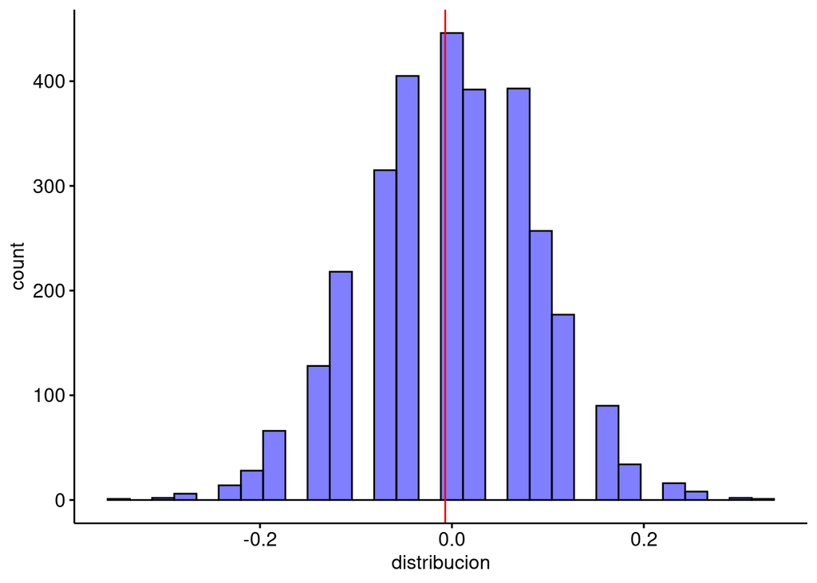

```r
p1 <- gghistogram(data.frame(distribucion), "distribucion", bins = 30, fill = "blue")
p1 <- p1 + geom_vline(xintercept = dif.obs, colour="red")
print(p1)
```

Podemos ver que la diferencia de las proporciones observada en la muestra original se ubica cerca del centro de distribución, no muy lejos del valor cero.

Calculemos el intervalo de 95% confianza y el valor p para una prueba bilateral, es decir la probabilidad de encontrar diferencias al menos tan extremas como la diferencia observada.

```r
ci1 <- quantile(distribucion, c(0.025, 0.975))
numerador1 <- sum(abs( distribucion) > abs(dif.obs))
valor_p1 <- (numerador1 + 1) / (R + 1)
```

Mostramos el resultado.

```r
cat("95% CI: [", round(ci1[1], 3), ", ", round(ci1[2], 3), "]\n", sep = "")
```

```
## 95% CI: [-0.175, 0.161]
```

```r
cat("P-valor:", round(valor_p1, 3))
```

```
## P-valor: 0.851
```

Mirando la distribución permutada de diferencias, el intervalo de confianza que representa ($[-0.18, 0.16]$) y el p-valor obtenido ($p = 0,851$), se puede concluir, con 95% confianza, que no hay evidencia suficiente para rechazar la hipótesis nula y tenemos que concluir que no es posible descartar que las proporciones de hombres y mujeres con problemas serios de movilidad que están cotizando para su jubilación son iguales.

## Pregunta 2

Propongan una pregunta de investigación original, que involucre la comparación de las medias de más de dos grupos independientes. Fijando una semilla distinta a la anterior, seleccionen una muestra aleatoria de hogares (200 < n < 300) y respondan la pregunta propuesta utilizando **bootstrapping**. Solo por ejercicio académico, aplique un análisis post-hoc con bootstrapping aunque este no sea necesario.

En este caso, consideraremos la pregunta: *¿es igual el ingreso per cápita en las regiones de Atacama, Coquimbo y del Maule?* Esta pregunta requiere contrastar las medias de 3 grupos independientes. Al haber más de dos medias, no es posible comparar directamente sus diferencias. Así, lo más conveniente en este caso es utilizar el **estadístico F** para evaluar su igualdad.

Filtremos los datos y obtengamos la muestra como se solicita.

```r
n2 <- 275
set.seed(572)
regiones <- c("Región de Coquimbo", "Región de Atacama", "Región del Maule")
muestra2 <- datos %>% filter(region %in% regiones) %>% droplevels() %>%
  mutate(region = recode(region, "Región de Atacama" = "Atacama")) %>%
  mutate(region = recode(region, "Región de Coquimbo" = "Coquimbo")) %>%
  mutate(region = recode(region, "Región del Maule" = "Maule")) %>%
  select(ytotcorh, numper, region) %>%
  mutate(ypercap = ytotcorh/numper, .keep = "unused") %>%
  sample_n(n2)
```

Formulamos las hipótesis:

::: hip

H$_0$: En promedio, el ingreso per cápita es igual en las regiones de Atacama, Coquimbo y el Maule.

H$_A$: En promedio, el ingreso per cápita es distinto en las regiones de Atacama, Coquimbo y el Maule.

Matemáticamente: si $\mu_{A}$, $\mu_{C}$ y $\mu_{M}$ representan las medias de los ingresos per cápita de las regiones de Atacama, Coquimbo y el Maule, entonces:

H$_0$: $\mu_{A}=\mu_{C}=\mu_{M}$.

H$_A$: $\exists$ al menos un par $a,b \in \{A, C, M\} \mid \mu_{a}\ne\mu_{b}$.

:::

Revisemos el tamaño de las muestras de observaciones en cada grupo.

```r
print(summary(muestra2[["region"]]))
```

```
##  Atacama Coquimbo    Maule
##       58       74      143
```

Ooops! Una complicación extra, puesto que las muestras tienen tamaños distintos y debemos **mantener esos tamaños** en el remuestreo. Separamos los índices de cada región con este objetivo en mente.

```r
iAtacama <- which(muestra2[["region"]] == "Atacama")
iCoquimbo <- which(muestra2[["region"]] == "Coquimbo")
iMaule <- which(muestra2[["region"]] == "Maule")
```

Revisemos los datos.

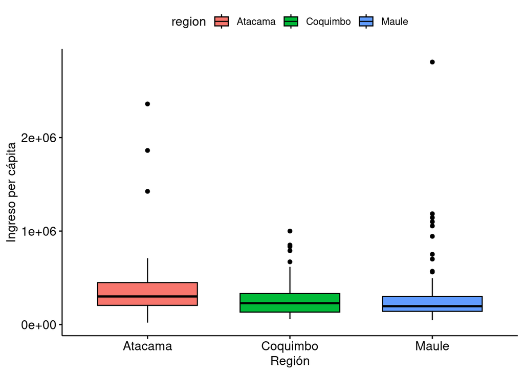

```r
p2 <- ggboxplot(muestra2, x = "region", y = "ypercap", fill = "region")
p2 <- p2 + xlab("Región") + ylab("Ingreso per cápita")
print(p2)
```

Podemos ver que los datos, además de estar desbalanceados, parecen no cumplir con la condición de heterocedasticidad y presentan numerosos valores atípicos. Este hecho es razón suficiente para ¡utilizar remuestreo!

Definimos una función que calcula el estadístico de interés que, como se dijo, corresponde al estadístico F usado por ANOVA para muestras independientes.

```r
get.F <- function(df, iA, iC, iM, verbose = FALSE)
{
  # Armamos la matriz de datos con los índices recibidos
  i <- c(iA, iC, iM)
  ids <- factor(1:length(i))
  datos <- cbind(id = ids, df[i, ])
  dd <<- datos

  ez <- ezANOVA(datos, ypercap, id, between = region, type = 2)
  if(verbose)
    print(ez)
  return(ez[["ANOVA"]][["F"]])
}
```

Obtenemos el estadístico para la muestra original.

```r
F.obs <- get.F(muestra2, iAtacama, iCoquimbo, iMaule, TRUE)
```

```
## $ANOVA
##   Effect DFn DFd        F        p p<.05        ges
## 1 region   2 272 4.557016 0.011307     * 0.03242112
##
## $`Levene's Test for Homogeneity of Variance`
##   DFn DFd          SSn          SSd        F         p p<.05
## 1   2 272 255519071781 1.913278e+13 1.816286 0.1645955
```

Debemos recordar que, a diferencia del caso anterior con permutaciones, con bootstrapping (al remuestrear con reemplazo la muestra original) las remuestras **no representan la hipótesis nula**. Cuando teníamos dos muestras, podíamos **recentrar** la distribución bootstrap en el valor nulo. Pero ¿cómo hacemos esto con el estadístico F?

Para ello debemos considerar que si la hipótesis nula se cumple, los tres grupos tienen las mismas medias y varianzas. Con más de dos grupos, es más fácil hacer estos ajustes **antes del remuestreo**. Para ello, nos basamos en las ideas propuestas por Fisher & Hall (1990), Hall & Wilson (1991) y Martin (2007).

Primero vamos a obtener las medidas generales (*pooled*).

```r
media.gral <- mean(muestra2[["ypercap"]])
sd.gral <- sd(muestra2[["ypercap"]])
```

Luego obtenemos las medidas por grupo (por región en este caso):

```r
grupos <- muestra2 %>%
  group_by(region) %>%
  summarise(media = mean(ypercap), sd = sd(ypercap)) %>%
  as.data.frame()
```

Ahora *desplazamos* los valores vistos para que los tres grupos tengan la misma media e igual varianza (en rigor, desviación estándar).

```r
muestra2b <- muestra2
muestra2b[iAtacama, "ypercap"] <- media.gral +
  (muestra2b[iAtacama, "ypercap"] - grupos[1, "media"]) *
  (sd.gral / grupos[1, "sd"])
muestra2b[iCoquimbo, "ypercap"] <- media.gral +
  (muestra2b[iCoquimbo, "ypercap"] - grupos[2, "media"]) *
  (sd.gral / grupos[2, "sd"])
muestra2b[iMaule, "ypercap"] <- media.gral +
  (muestra2b[iMaule, "ypercap"] - grupos[3, "media"]) *
  (sd.gral / grupos[3, "sd"])
```

Generamos las remuestras muestreando con reemplazo los índices de los datos de cada grupo.

```r
B <- 2999
set.seed(573)
re.iAtacama <- lapply(1:B, function(i) sample(iAtacama, replace = TRUE))
re.iCoquimbo <- lapply(1:B, function(i) sample(iCoquimbo, replace = TRUE))
re.iMaule <- lapply(1:B, function(i) sample(iMaule, replace = TRUE))
```

Obtenemos la distribución bootstrapping remuestreando cada región por separado.

```r
cat("Remuestreando, por favor espere...\n")
```

```
## Remuestreando, por favor espere...
```

```r
get.F.boot <- function(i, df, verbose = FALSE)
  get.F(df, re.iAtacama[[i]], re.iCoquimbo[[i]], re.iMaule[[i]], verbose)
distribucion <- sapply(1:B, function(i) get.F.boot(i, muestra2b, B < 10))
```

Revisemos cómo se ve esta distribución respecto del valor observado en la muestra original.

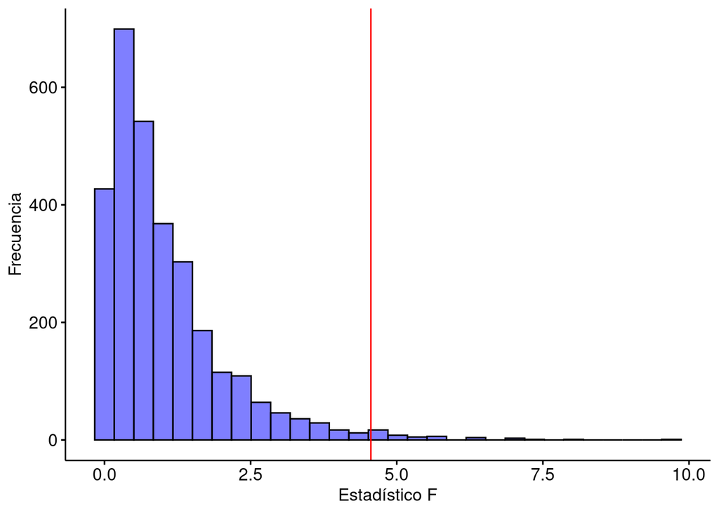

```r
p2 <- gghistogram(data.frame(distribucion), "distribucion",
                  xlab = "Estadístico F", ylab = "Frecuencia",
                  bins = 30, fill = "blue")
p2 <- p2 + geom_vline(xintercept = F.obs, colour="red")
print(p2)
```

Calculemos el intervalo de 95% confianza y el valor p para una prueba bilateral (usando valor absoluto).

```r
ci2 <- quantile(distribucion, c(0.025, 0.975))
numerador2 <- sum(abs(distribucion) > abs(F.obs))
valor_p2 <- (numerador2 + 1) / (B + 1)
```

Mostramos el resultado.

```r
cat("95% CI: [", round(ci2[1], 3), ", ", round(ci2[2], 3), "]\n", sep = "")
```

```
## 95% CI: [0.034, 3.837]
```

```r
cat("P-valor:", round(valor_p2, 3))
```

```
## P-valor: 0.015
```

Observamos que si la hipótesis nula es correcta, los estadísticos F que observaríamos estarían en el intervalo $[0,034; 3,837]$ con 95% confianza. Como el estadístico F observado (en la muestra original) fue $F=4,557$, que tiene una baja probabilidad de ser encontrado ($p = 0,015$), se rechaza la hipótesis nula en favor de la alternativa. Concluimos entonces, con 95% confianza, que el ingreso per cápita promedio no es igual en las regiones estudiadas. Corresponde, entonces, hacer un análisis post-hoc.

Por conveniencia, haremos comparación entre pares de regiones usando las mismas remuestras que usamos en la prueba ómnibus. Al analizar pares de regiones, podemos usar la **diferencia de las medias** como estadístico de interés.

Escribamos la típica función que calcula esta diferencia.

```r
get.dif.medias <- function(df, i1, i2)
{
  media1 <- mean(df[i1, "ypercap"])
  media2 <- mean(df[i2, "ypercap"])
  return(media1 - media2)
}
```

Obtenemos las diferencias observadas entre cada par de regiones.

```r
dif.obs.A.C <- get.dif.medias(muestra2, iAtacama, iCoquimbo)
dif.obs.A.M <- get.dif.medias(muestra2, iAtacama, iMaule)
dif.obs.C.M <- get.dif.medias(muestra2, iCoquimbo, iMaule)
cat("Atacama - Coquimbo:", round(dif.obs.A.C), "\n")
```

```
## Atacama - Coquimbo: 128427
```

```r
cat("Atacama - Maule:", round(dif.obs.A.M), "\n")
```

```
## Atacama - Maule: 134652
```

```r
cat("Coquimbo - Maule:", round(dif.obs.C.M), "\n")
```

```
## Coquimbo - Maule: 6225
```

Obtenemos las distribuciones bootstrap para cada diferencia.

```r
dist.boot.dif.A.C <- sapply(1:B,
                            function(i) get.dif.medias(muestra2b,
                                                       re.iAtacama[[i]],
                                                       re.iCoquimbo[[i]]))
dist.boot.dif.A.M <- sapply(1:B,
                            function(i) get.dif.medias(muestra2b,
                                                       re.iAtacama[[i]],
                                                       re.iMaule[[i]]))
dist.boot.dif.C.M <- sapply(1:B,
                            function(i) get.dif.medias(muestra2b,
                                                       re.iCoquimbo[[i]],
                                                       re.iMaule[[i]]))
```

Y las graficamos (en miles de pesos).

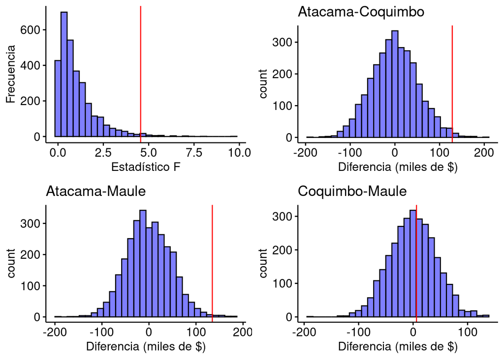

```r
p3a <- gghistogram(data.frame(Diferencia = dist.boot.dif.A.C / 1000),
                   "Diferencia", title = "Atacama-Coquimbo", xlab = "Diferencia (miles de $)",
                   bins = 30, fill = "blue")
p3a <- p3a + geom_vline(xintercept = dif.obs.A.C / 1000, colour="red")
p3b <- gghistogram(data.frame(Diferencia = dist.boot.dif.A.M / 1000),
                   "Diferencia", title = "Atacama-Maule", xlab = "Diferencia (miles de $)",
                   bins = 30, fill = "blue")
p3b <- p3b + geom_vline(xintercept = dif.obs.A.M / 1000, colour="red")
p3c <- gghistogram(data.frame(Diferencia = dist.boot.dif.C.M / 1000),
                   "Diferencia", title = "Coquimbo-Maule", xlab = "Diferencia (miles de $)",
                   bins = 30, fill = "blue")
p3c <- p3c + geom_vline(xintercept = dif.obs.C.M / 1000, colour="red")
p3 <- ggarrange(p2, p3a, p3b, p3c, nrow = 2, ncol = 2)
print(p3)
```

En los gráficos queda bastante claro dónde están las diferencias, pero para seguir con el ejercicio, calculamos los p-valores ajustados.

```r
valor_p.A.C <- (sum(abs(dist.boot.dif.A.C) > abs(dif.obs.A.C)) + 1) / (B + 1)
valor_p.A.M <- (sum(abs(dist.boot.dif.A.M) > abs(dif.obs.A.M)) + 1) / (B + 1)
valor_p.C.M <- (sum(abs(dist.boot.dif.C.M) > abs(dif.obs.C.M)) + 1) / (B + 1)
valores_p.adj <- p.adjust(c(valor_p.A.C, valor_p.A.M, valor_p.C.M), method = "BH")
cat("Atacama - Coquimbo:", round(valores_p.adj[1], 3), "\n")
```

```
## Atacama - Coquimbo: 0.02
```

```r
cat("Atacama - Maule:", round(valores_p.adj[2],3), "\n")
```

```
## Atacama - Maule: 0.02
```

```r
cat("Coquimbo - Maule:", round(valores_p.adj[3], 3), "\n")
```

```
## Coquimbo - Maule: 0.885
```

También podemos usar las remuestras para estimar los intervalos de confianza de las diferencias de las medias de ingresos per cápita entre las regiones observadas en en estudio.

```r
dist.boot.dif.obs.A.C <- sapply(1:B,
                                 function(i) get.dif.medias(muestra2,
                                                            re.iAtacama[[i]],
                                                            re.iCoquimbo[[i]]))
dist.boot.dif.obs.A.M <- sapply(1:B,
                                 function(i) get.dif.medias(muestra2,
                                                            re.iAtacama[[i]],
                                                            re.iMaule[[i]]))
dist.boot.dif.obs.C.M <- sapply(1:B,
                                 function(i) get.dif.medias(muestra2,
                                                            re.iCoquimbo[[i]],
                                                            re.iMaule[[i]]))

ci.dif.obs.A.C <- quantile(dist.boot.dif.obs.A.C, c(0.025, 0.975))
ci.dif.obs.A.M <- quantile(dist.boot.dif.obs.A.M, c(0.025, 0.975))
ci.dif.obs.C.M <- quantile(dist.boot.dif.obs.C.M, c(0.025, 0.975))

cat("Intervalos de 95% confianza:\n")
```

```
## Intervalos de 95% confianza:
```

```r
cat("Atacama - Coquimbo: [", round(ci.dif.obs.A.C[1], 3), ", ", round(ci.dif.obs.A.C[2], 3), "]\n)", sep = "")
```

```
## Atacama - Coquimbo: [26630.42, 242873.9]
## )
```

```r
cat("Atacama - Maule   : [", round(ci.dif.obs.A.M[1], 3), ", ", round(ci.dif.obs.A.M[2], 3), "]\n)", sep = "")
```

```
## Atacama - Maule   : [29800.36, 248522.9]
## )
```

```r
cat("Coquimbo - Maule  : [", round(ci.dif.obs.C.M[1], 3), ", ", round(ci.dif.obs.C.M[2], 3), "]\n)", sep = "")
```

```
## Coquimbo - Maule  : [-61347.28, 68950.19]
## )
```

En base al procedimiento post-hoc, podemos concluir con 95% de confianza que no hay diferencias significativas en el ingreso per cápita promedio de las regiones de Coquimbo y del Maule (95% IC:$[-\$61.347, \$68.950], p = 0,885$), pero que estos son significativamente menores al ingreso per cápita promedio de la región de Atacama (Coquimbo: 95% IC:$[\$26.630, \$242.873], p=0,020$; Maule: 95% IC:$[\$29.800, \$248.522], p=0,020$).

## Referencias

Fisher, N. I., & Hall, P. (1990). On bootstrap hypothesis testing. Australian Journal of Statistics, 32(2), 177-190.

Hall, P., & Wilson, S. R. (1991). Two guidelines for bootstrap hypothesis testing. Biometrics, 757-762.

Martin, M. A. (2007). Bootstrap hypothesis testing for some common statistical problems: A critical evaluation of size and power properties. Computational Statistics & Data Analysis, 51(12), 6321-6342.